# Project #7: Exploring Red Wines

## I’ll plot the rest four variables vs. quality with removing some outliers.

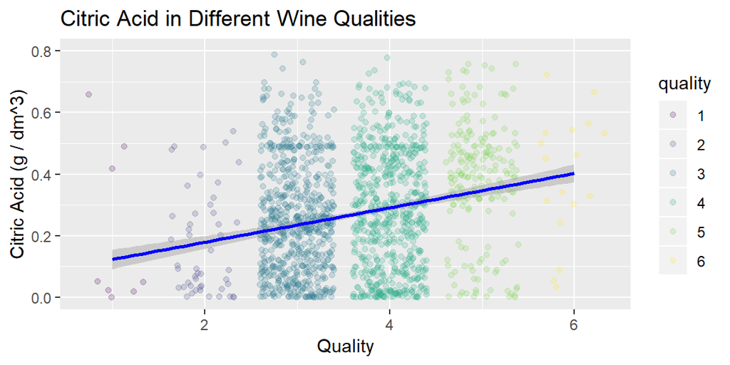

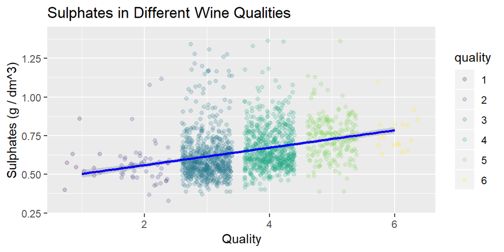

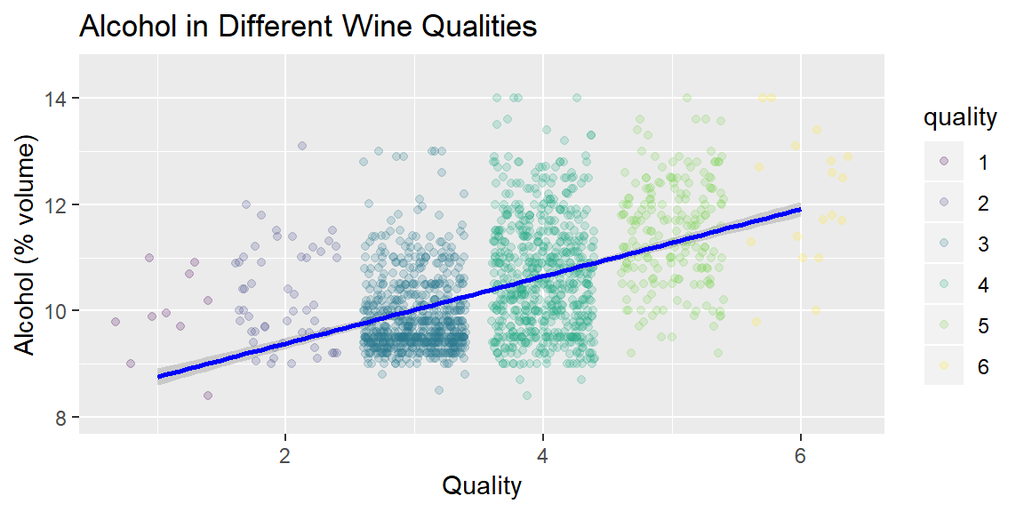

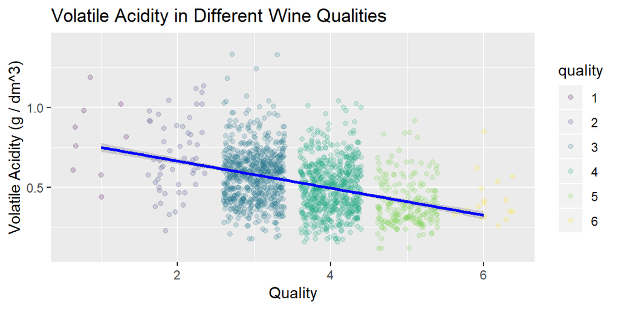

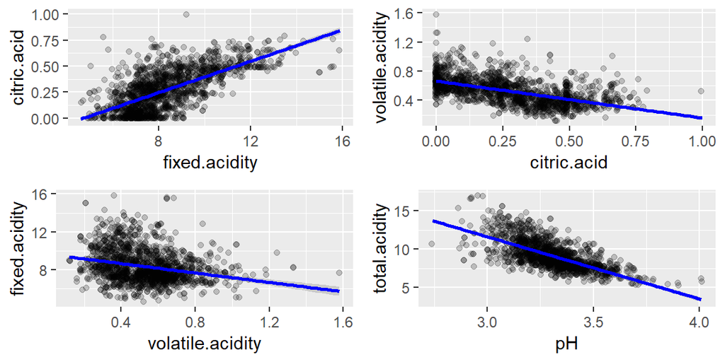

- higer fixed.acidity, citric.acid, sulphates, and alcohol
- lower volatile.acidity, chlorides and density

### Talk about some of the relationships you observed in this part of the investigation. How did the feature(s) of interest vary with other features in the dataset?

From the boxplot, I found some trends that a good red wine has. After the caluculation of eight variables against the quality of red wine and create scatterplot, four rariables were removed, and the result is a good wine seems has the following characteristic:

- higer fixed.acidity, citric.acid, sulphates, and alcohol.
- lower volatile.acidity, chlorides and density.

### Did you observe any interesting relationships between the other features (not the main feature(s) of interest)?

From the scatter plots I observed the correlations between acid variables, and ph vs. total.acidity, results are as follows:

- fixed.acidity & citric.acid : 0.67
- citric.acid & volatile.acidity: -0.55
- volatile.acidity & fixed.acidity: -0.25
- PH & total.acidity: -0.68

### What was the strongest relationship you found?

The strongest relationship I found is PH vs.total.acidity, which is more than -0.68, and the second is correlation between fixed.acidity and citric.acid(0.6717034).

# Multivariate Plots Section

Alcohol has the highest correlation with the quality of red wines, so I will create multivariate plots that are alohol vs. other three variables and rating. For the rating, I will remove average rating before plot because average has the most quantities, remove it can make the plot more obvious to find the differences between ‘good’ and ‘bad’.

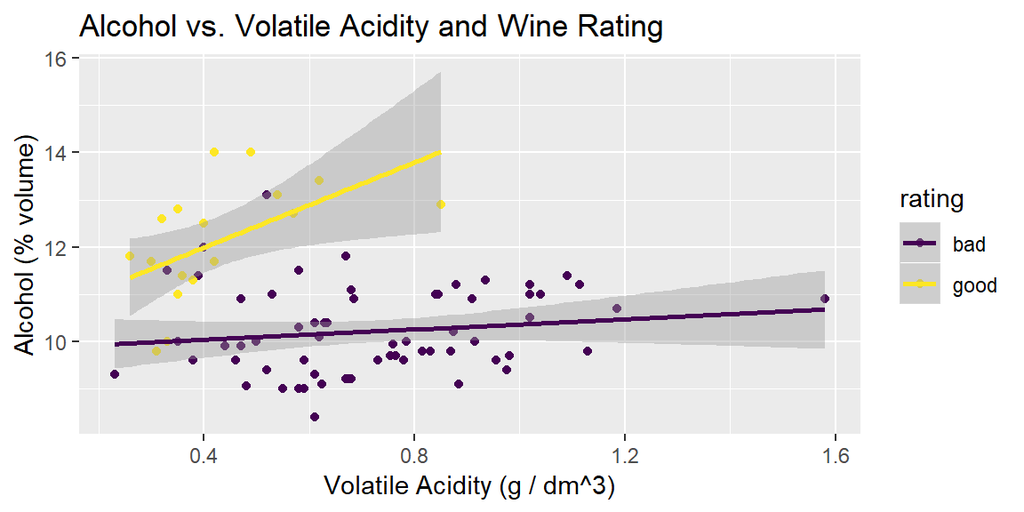

For a ‘good’ red wine, it has higher alcohol and lower volatile.acidity, and it has more positive correlation between alcohol and volatile.acidity.

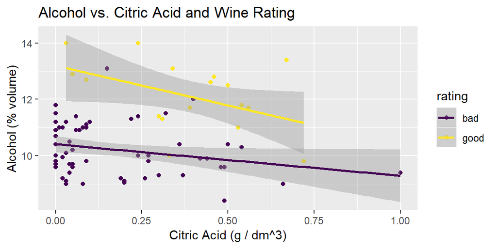

For a ‘good’ red wine, it has higher alcohol but is not clear for volatile.acidity, and it has more negative correlation between alcohol and citric.acid.

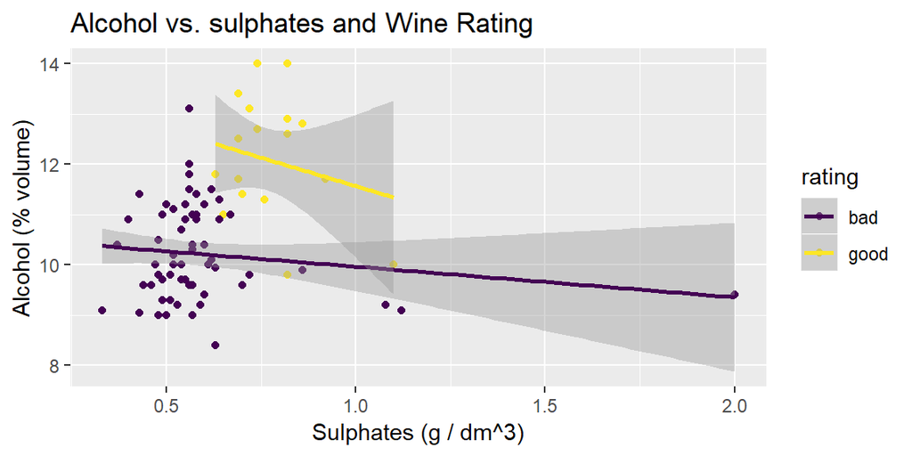

For a ‘good’ red wine, it has higher alcohol and higer sulphates, and it has more negative correlation between alcohol and sulphates. # Multivariate Analysis

### Talk about some of the relationships you observed in this part of the investigation. Were there features that strengthened each other in terms of looking at your feature(s) of interest?

Only one thing can be comfirmed, that is good red wine have higer alcohol. Other three factors have limit influence on quality of red wine. ### Were there any interesting or surprising interactions between features?

The cititric.acid for both good or bad red wind doesn’t have clear differences.

### OPTIONAL: Did you create any models with your dataset? Discuss the strengths and limitations of your model.

# Final Plots and Summary

### Plot One

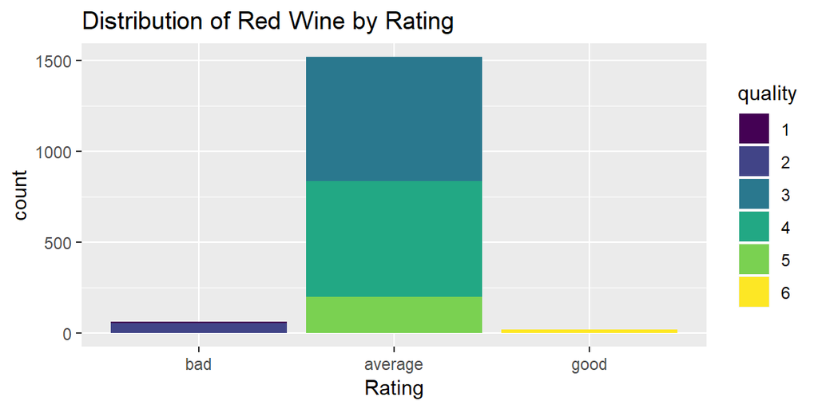

### Plot Two

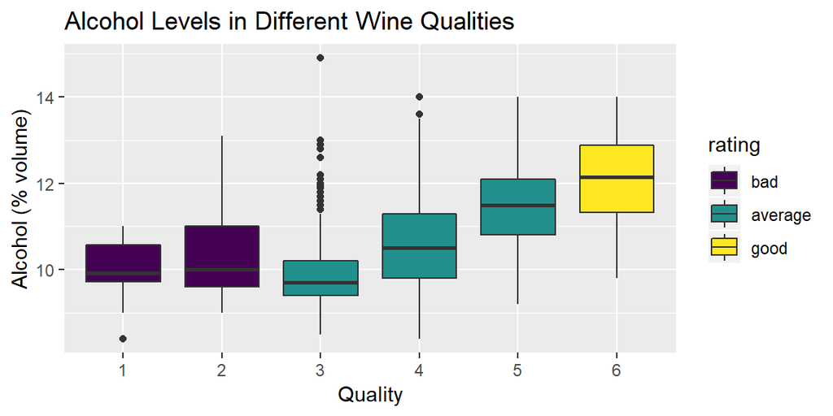

### Plot Three

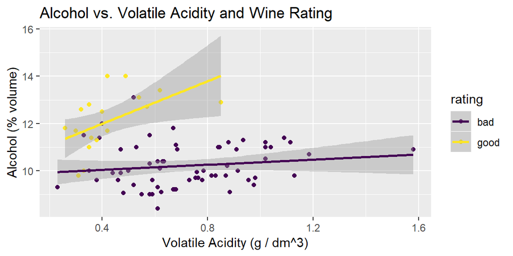

### Description Three

After remove the avearge rating wind data, this scatterplot shows the realationship between alcohol and the quality of red wine again. Additionaly, the realationship of vlotile.acidity and quality can be seen from this plot, higer quality red wine has lower volatile.acidity. And the good wine has more positive correlation between alcohol and volatile.acidity.

# Reflection

The object of this exploratory data analysis is to find out which chemical properties would afftect the quality of red wines.In order to obverse the quality more directly, I divided the quality into new three rating: bad, average and good. I plotted and calculated the correlations between quality and the variables. However, after all these anaysis, I found none of the correlations were above 0.7. Alcohol is the most important facor that influence the quality of red wines, the acidity also affect the quality to some extent. I hvae to say the measure of red wine quality is subjective, which means the data analysis is not enough to reveal all factors and to rate a res wine.